# Project2

Serg C

August 18, 2017

## Rep Course Project 2

This project includes several parts.

## 1. Reading the dataset

The dataset is downloaded and unzipped, and then `dt` data.frame is read from `activity.csv` file:

```r
dt <- read.csv( paste( wdir,"activity.csv",sep="/") )
```

## 2. Histogram of the total number of steps taken each day

Calculate the total number of steps taken per day, ignore NAs.

```r
tot <- tapply( dt$steps,dt$date, sum, na.rm=TRUE )
```

Make a histogram of the total number of steps taken each day

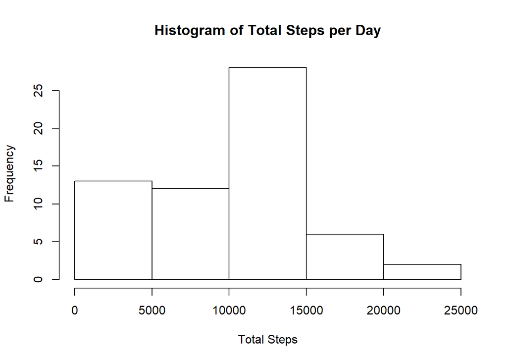

```r
hist( tot, main='Histogram of Total Steps per Day',xlab='Total Steps')
```

## 3. Mean and median number of steps taken each day

The report record is formatted as < date, median, mean, max >

```r
rep <- aggregate( steps~date, data=dt, function(x){summary(x, digits=2)})
day <- data.frame( unclass(rep), check.names = FALSE, stringsAsFactors = FALSE)[,c(1,4,5,7)]
names(day) <- c('date','median','mean','max')
print(day,row.names=F)
```

```
##        date median  mean max
##  2012-10-02      0  0.44 120
##  2012-10-03      0 39.00 610
##  2012-10-04      0 42.00 550
##  2012-10-05      0 46.00 560
##  2012-10-06      0 54.00 530
##  2012-10-07      0 38.00 520
##  2012-10-09      0 44.00 750
##  2012-10-10      0 34.00 410
##  2012-10-11      0 36.00 750
##  2012-10-12      0 60.00 800
##  2012-10-13      0 43.00 540
##  2012-10-14      0 52.00 540
##  2012-10-15      0 35.00 790
##  2012-10-16      0 52.00 760
##  2012-10-17      0 47.00 740
##  2012-10-18      0 35.00 760
##  2012-10-19      0 41.00 510
##  2012-10-20      0 36.00 530
##  2012-10-21      0 31.00 500
##  2012-10-22      0 47.00 780
##  2012-10-23      0 31.00 500
##  2012-10-24      0 29.00 530
##  2012-10-25      0  8.70 440
##  2012-10-26      0 24.00 440
##  2012-10-27      0 35.00 560
##  2012-10-28      0 40.00 530
##  2012-10-29      0 17.00 590
##  2012-10-30      0 34.00 520
##  2012-10-31      0 54.00 760
##  2012-11-02      0 37.00 750
##  2012-11-03      0 37.00 530
##  2012-11-05      0 36.00 780
##  2012-11-06      0 29.00 630
##  2012-11-07      0 45.00 770
##  2012-11-08      0 11.00 360
##  2012-11-11      0 44.00 540
##  2012-11-12      0 37.00 540
##  2012-11-13      0 25.00 440
##  2012-11-15      0  0.14  33
##  2012-11-16      0 19.00 480
##  2012-11-17      0 50.00 750
##  2012-11-18      0 52.00 780
##  2012-11-19      0 31.00 790
##  2012-11-20      0 16.00 500
##  2012-11-21      0 44.00 760
##  2012-11-22      0 71.00 570
##  2012-11-23      0 74.00 760
##  2012-11-24      0 50.00 780
##  2012-11-25      0 41.00 550
##  2012-11-26      0 39.00 710
##  2012-11-27      0 47.00 810
##  2012-11-28      0 35.00 730
##  2012-11-29      0 24.00 570
```

## 4. Time series plot of the average number of steps taken

Make a time series plot of the 5-minute interval (x-axis) and the average number of steps taken, averaged across all days (y-axis).

Calculate

```r
rep <- aggregate( steps~interval, data=dt, mean, na.rm=TRUE )
```

then plot

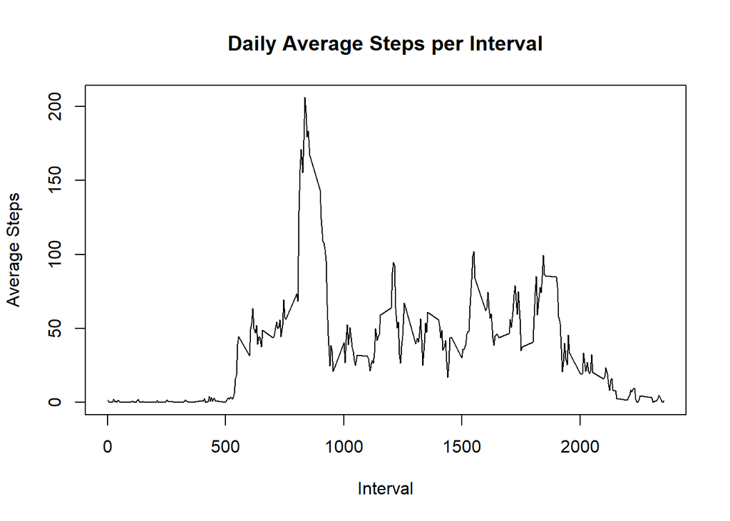

```r
with(rep,plot(interval,steps,type='l',
    main='Daily Average Steps per Interval',ylab='Average Steps',xlab='Interval'))
```

## 5. The 5-minute interval that, on average, contains the maximum number of steps

```r
int <- rep[which(rep$steps==max(rep$steps)),"interval"]
```

**Q:** Which 5-minute interval, on average across all the days in the dataset, contains the maximum number of steps?

**A:** The interval that contains the maximum number of steps on average is *835*.

[output not shown]

## 6. Code to describe and show a strategy for inputing missing data

1. Calculate and report the total number of missing values in the dataset

```r
dt_na <- is.na(dt$steps)
print( sum(dt_na), row.names=F )
```

```
## [1] 2304
```

2. My strategy to fill in NA’s is replace NA Steps observation with the average of value of Steps claculated for the same interval in item 4. Wewill merge the original `dt` and `rep` frames, then re-set NA’s then make a new dataset.
3. Create a new dataset that is equal to the original dataset but with the missing data filled in.

```r
dt.new <- merge( dt, rep, by='interval' )
dt.new[ is.na(dt.new[,2]), 2] <- dt.new[ is.na(dt.new[,2]), 4]
dt.new <- dt.new[,c(2,3,1)]
names(dt.new)<-c('steps','date','interval')
```

## 7. Histogram of the total number of steps taken each day after missing values are fixed

Calculate the total number of steps taken per day.

```r
tot <- tapply( dt.new$steps, dt.new$date, sum )
```

Make a histogram of the total number of steps taken each day (fixed data frame)

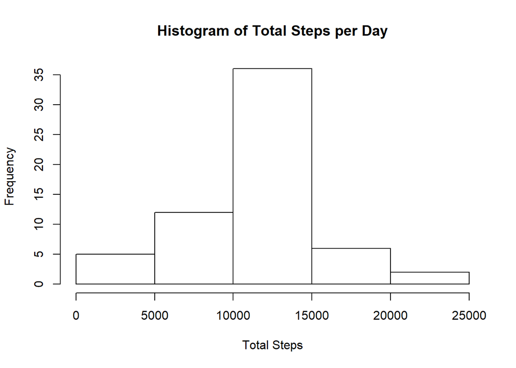

```r
hist( tot, main='Histogram of Total Steps per Day',xlab='Total Steps')
```

The report record is formatted as < date, median, mean, max >

```r
rep <- aggregate( steps~date, data=dt.new, function(x){summary(x, digits=2)})
day <- data.frame( unclass(rep), check.names = FALSE, stringsAsFactors = FALSE)[,c(1,4,5,7)]
names(day) <- c('date','median','mean','max')
print(day,row.names=F)
```

```
##        date median  mean max
##  2012-10-01     34 37.00 210
##  2012-10-02      0  0.44 120
##  2012-10-03      0 39.00 610
##  2012-10-04      0 42.00 550
##  2012-10-05      0 46.00 560
##  2012-10-06      0 54.00 530
##  2012-10-07      0 38.00 520
##  2012-10-08     34 37.00 210
##  2012-10-09      0 44.00 750
##  2012-10-10      0 34.00 410
##  2012-10-11      0 36.00 750
##  2012-10-12      0 60.00 800
##  2012-10-13      0 43.00 540
##  2012-10-14      0 52.00 540
##  2012-10-15      0 35.00 790
##  2012-10-16      0 52.00 760
##  2012-10-17      0 47.00 740
##  2012-10-18      0 35.00 760
##  2012-10-19      0 41.00 510
##  2012-10-20      0 36.00 530
##  2012-10-21      0 31.00 500
##  2012-10-22      0 47.00 780
##  2012-10-23      0 31.00 500
##  2012-10-24      0 29.00 530
##  2012-10-25      0  8.70 440
##  2012-10-26      0 24.00 440
##  2012-10-27      0 35.00 560
##  2012-10-28      0 40.00 530
##  2012-10-29      0 17.00 590
##  2012-10-30      0 34.00 520
##  2012-10-31      0 54.00 760
##  2012-11-01     34 37.00 210
##  2012-11-02      0 37.00 750
##  2012-11-03      0 37.00 530
##  2012-11-04     34 37.00 210
##  2012-11-05      0 36.00 780
##  2012-11-06      0 29.00 630
##  2012-11-07      0 45.00 770
##  2012-11-08      0 11.00 360
##  2012-11-09     34 37.00 210
##  2012-11-10     34 37.00 210
##  2012-11-11      0 44.00 540
##  2012-11-12      0 37.00 540
##  2012-11-13      0 25.00 440
##  2012-11-14     34 37.00 210
##  2012-11-15      0  0.14  33
##  2012-11-16      0 19.00 480
##  2012-11-17      0 50.00 750
##  2012-11-18      0 52.00 780
##  2012-11-19      0 31.00 790
##  2012-11-20      0 16.00 500
##  2012-11-21      0 44.00 760
##  2012-11-22      0 71.00 570
##  2012-11-23      0 74.00 760
##  2012-11-24      0 50.00 780
##  2012-11-25      0 41.00 550
##  2012-11-26      0 39.00 710
##  2012-11-27      0 47.00 810
##  2012-11-28      0 35.00 730
##  2012-11-29      0 24.00 570
##  2012-11-30     34 37.00 210
```

**Q:** Do these values differ from the estimates from the first part of the assignment?

**A:** Yes

**Q:** What is the impact of fixing missing data on the estimates of the total daily number of steps?

**A:** The total daily number of steps has increased.

## 8. Panel plot comparing the average number of steps taken per 5-minute interval across weekdays and weekends

Modify`dt.new` data frame to add a new column, calculate df to plot

```r
dt.new$day <- ifelse(
    weekdays(as.Date(dt.new$date,'%Y-%m-%d')) %in% c('Sunday','Saturday' ),
    'weekend', 'weekday')
wd <- aggregate( steps~interval, data=subset(dt.new, day=='weekday'), mean )
we <- aggregate( steps~interval, data=subset(dt.new, day=='weekend'), mean )
```

Make a panel plot

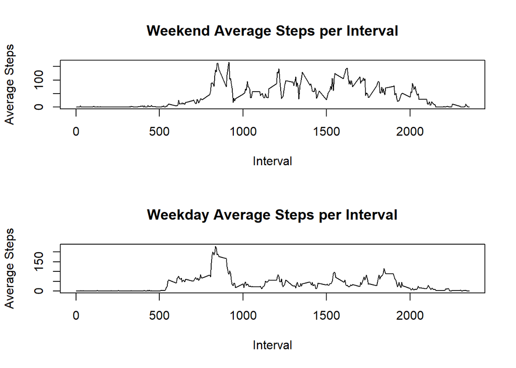

```r
par(mfrow = c(2, 1))
with(we,plot(interval,steps,type='l',
    main='Weekend Average Steps per Interval',ylab='Average Steps',xlab='Interval'))

with(wd,plot(interval,steps,type='l',
    main='Weekday Average Steps per Interval',ylab='Average Steps',xlab='Interval'))
```

## 9. URL to GitHub report

[rep_proj_2.html] (http://htmlpreview.github.com/?https://github.com/about-r/RepData_PeerAssessment1/master/rep_proj_2.html)